# ML Assignment

Rithvik

2023-04-04

# Introduction

This document describes use of ML models for prediction of exercise type in a given dataset called the Weight Lifting Exercise Dataset. The data was collected from accelerometers on the belt, forearm, arm, and dumbell of 6 participants. They were asked to perform barbell lifts correctly and incorrectly in 5 different ways. http://groupware.les.inf.puc-rio.br/har For this purpose, we need to load the dataset, train an ML model and use the model to predict the exercise method for the test data.

# Data loading and cleaning

## Download data

The data is downloaded and loaded as `maindata` and `outsample` using read.csv and default options.

```r
maindata <- read.csv("https://d396qusza40orc.cloudfront.net/predmachlearn/pml-training.csv")
outsample <- read.csv("https://d396qusza40orc.cloudfront.net/predmachlearn/pml-testing.csv")
```

## Clean data

We can use `View()` in RStudio to check the data. `dim(maindata)=`19622, 160 and `dim(outsample)=`20, 160. The number of columns is the same, however maindata has a `classe` column, while outsample has a dummy variable `problem_id` which is a counter 1:20. We note that many columns are having NA values, except when the `new_window` column has value `yes`. In the latter case, there are values instead of NA. The outsample data has no `new_window` values given as `yes`. Thus it is better to filter out all entries where `new_window=="yes"`. The number of entries with `new_window=="yes"` is very small, i.e.`dim(maindata[maindata$new_window=="yes",])=`406, 160 compared to 19216 entries for `new_window=="no"`. Since the function of the `new_window` column is not clear, we will use the `new_window=="no"` entries only.

```r
maindata <- maindata[maindata$new_window=="no",]
```

This makes several columns with NA values. These can be removed immediately from both maindata and outsample. We will check that no extra columns are removed and the maindata and sample match.

```r
contains_any_na = sapply(outsample, function(x) any(is.na(x)))
maindata <- maindata[,!contains_any_na]
outsample <- outsample[,!contains_any_na]
```

The first 6 columns are removed and preserved in another variable in case we need it later. The same procedure is used on both the maindata and outsample.

```r
maindata_1st6 <- maindata[,c(1:6)]
maindata <- maindata[,-c(1:6)]
```

```r
outsample_1st6 <- outsample[,c(1:6)]
outsample <- outsample[,-c(1:6)]
```

We can make factor variable out of the classe column.

```r
maindata$classe <- as.factor(maindata$classe)
```

The new dataset is now defined as dim(maindata)=19216, 54. And the outsample is dim(outsample)=20, 54. Thus we have 54 variables in both. There are `dim(maindata)[1]` entries in the maindata for training.

# Machine learning

We first load the library needed

```r
library(caret)
```

First we will split the maindata into a training and test set, so we can choose the best machine learning strategy.

```r
inTrain <- createDataPartition(maindata$classe, p = 3/4)[[1]]
training <- maindata[inTrain,]
testing <- maindata[-inTrain,]
```

Using this strategy we can try many methods

```r
rpartFit <- train(classe ~ ., data = training, method = "rpart")
```

```r
pred_rpart <- predict(rpartFit, newdata = testing[,-55], type = "raw")
```

```r
cMpred_rpart <- confusionMatrix(data=pred_rpart, reference=testing$classe)
cMpred_rpart$table
```

```
##           Reference
## Prediction    A    B    C    D    E
##          A 1240  385  374  338   92
##          B   20  294   29  122   68
##          C  103  250  435  288  179
##          D    0    0    0    0    0
##          E    4    0    0   38  543
```

```r
cMpred_rpart$overall
```

```
##       Accuracy          Kappa  AccuracyLower  AccuracyUpper   AccuracyNull
##   5.231154e-01   3.778788e-01   5.088740e-01   5.373286e-01   2.846731e-01
## AccuracyPValue  McnemarPValue
##  5.097330e-263   0.000000e+00
```

Clearly the Classification and Regression Trees (CART) model is not very accurate with 52.3115369% accuracy by default. It may work with some tweaking. Other methods like “glm” or “lm” do not work as the number of variables is very large, or in case of “glm”, the output levels are too many.

Boost methods combine many different small regressors using different strategies. One commonly used boost method which requires very little tweaking from default is the “gbm” or Gradient boosting machine. We can use this technique as it is perfect for the use-case we have.

```r
gbmFit <- train(classe ~ ., data = training,
                 method = "gbm",
                 verbose = FALSE)
```

```r
pred_gbm <- predict(gbmFit, newdata = testing[,-55], type = "raw")
```

```r
cMpred_gbm <- confusionMatrix(data=pred_gbm, reference=testing$classe)
cMpred_gbm$table
```

```
##           Reference
## Prediction    A    B    C    D    E
##          A 1366    7    0    0    0
##          B    1  916    4    0    1
##          C    0    6  834    8    1
##          D    0    0    0  778    3
##          E    0    0    0    0  877
```

```r
cMpred_gbm$overall[1:2]
```

```
##  Accuracy     Kappa
## 0.9935444 0.9918329
```

We can see that the training confusionmatrix gives 99.3544357% accuracy. This is much better than “rpart”. Thus we can use the “gbm” model for our final analysis

# Cross Validation

There are many methods for cross validation. One we have already used, by partitioning the data into training and testing sets. However, we can use more rigorous methods on the whole maindata so that we can have a model which we can then use on the outsample. We can use “cv” or “repeatcv” or k-fold cross validations. We can use K=10 and 10 repeats of the same with “repeatcv”, and then take the average to remove any bias in sampling.

```r
fitControl <- trainControl( method = "repeatedcv",number = 10, repeats = 10)
set.seed(1729)
```

The seed can be anything, including the [taxicab number](https://en.wikipedia.org/wiki/Taxicab_number).

```r
gbmFit1 <- train(classe ~ ., data = maindata,
                 method = "gbm",
                 trControl = fitControl,
                 verbose = FALSE)
```

```r
pred_gbm1 <- predict(gbmFit1, newdata = testing[, -55], type = "raw")
```

```r
cMpred_gbm1 <- confusionMatrix(data=pred_gbm1, reference=testing$classe)
cMpred_gbm1$table
```

```
##           Reference
## Prediction    A    B    C    D    E
##          A 1367    7    0    0    0
##          B    0  914    4    1    1
##          C    0    8  830    5    2
##          D    0    0    4  779    1
##          E    0    0    0    1  878
```

```r
cMpred_gbm1$overall[1:2]
```

```
##  Accuracy     Kappa
## 0.9929196 0.9910423
```

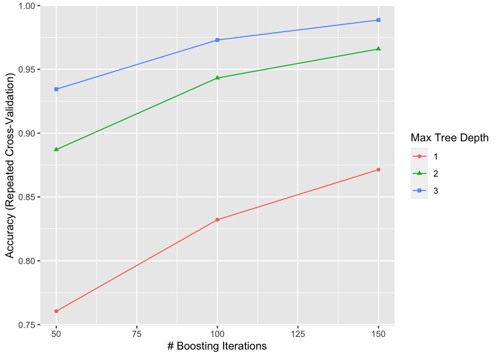

We can see the increase in estimated accuracy as the boosting iterations are increased

```r
ggplot(gbmFit1)
```

# Application of the model

The model can now be applied to our ‘outsample’

```r
pred_prob <- predict(gbmFit1, newdata = outsample, type = "prob")
pred_prob
```

```
##              A           B           C           D           E
## 1  0.033040721 0.741904611 0.074388315 0.124448729 0.026217625
## 2  0.963376407 0.022463159 0.006724335 0.002474260 0.004961839
## 3  0.086674482 0.764112643 0.073339417 0.025902206 0.049971252
## 4  0.977201649 0.003466924 0.007744126 0.010331798 0.001255503
## 5  0.964052169 0.020517439 0.007199514 0.003203078 0.005027800
## 6  0.003243891 0.034362431 0.043298497 0.023433657 0.895661524
## 7  0.014690747 0.055825630 0.055952131 0.835917978 0.037613515
## 8  0.030809868 0.609817504 0.045581013 0.273177569 0.040614045
## 9  0.990889738 0.004900352 0.001416386 0.001557325 0.001236200
## 10 0.952591417 0.026443982 0.010538029 0.006392331 0.004034242
## 11 0.017669826 0.940786438 0.018205648 0.010656967 0.012681120
## 12 0.018603451 0.027412596 0.905714049 0.020497202 0.027772702
## 13 0.019819450 0.898983430 0.014497135 0.020633922 0.046066063
## 14 0.992136850 0.002679342 0.002681833 0.001039602 0.001462373
## 15 0.003829300 0.019783358 0.008456394 0.032019884 0.935911064
## 16 0.007426780 0.010303652 0.002046778 0.011036932 0.969185859
## 17 0.934320197 0.006938441 0.007625800 0.002439096 0.048676466
## 18 0.050158879 0.864021036 0.005233146 0.058501812 0.022085127
## 19 0.234776584 0.682581228 0.013859519 0.054279153 0.014503515
## 20 0.003519166 0.985268288 0.002203913 0.002613723 0.006394910
```

We can see some columns having $p>0.6$, which are the predictions of the model.

```r
pred_mat <- pred_prob>0.6
pred_mat
```

```
##           A     B     C     D     E
##  [1,] FALSE  TRUE FALSE FALSE FALSE
##  [2,]  TRUE FALSE FALSE FALSE FALSE
##  [3,] FALSE  TRUE FALSE FALSE FALSE
##  [4,]  TRUE FALSE FALSE FALSE FALSE
##  [5,]  TRUE FALSE FALSE FALSE FALSE
##  [6,] FALSE FALSE FALSE FALSE  TRUE
##  [7,] FALSE FALSE FALSE  TRUE FALSE
##  [8,] FALSE  TRUE FALSE FALSE FALSE
##  [9,]  TRUE FALSE FALSE FALSE FALSE
## [10,]  TRUE FALSE FALSE FALSE FALSE
## [11,] FALSE  TRUE FALSE FALSE FALSE
## [12,] FALSE FALSE  TRUE FALSE FALSE
## [13,] FALSE  TRUE FALSE FALSE FALSE
## [14,]  TRUE FALSE FALSE FALSE FALSE
## [15,] FALSE FALSE FALSE FALSE  TRUE
## [16,] FALSE FALSE FALSE FALSE  TRUE
## [17,]  TRUE FALSE FALSE FALSE FALSE
## [18,] FALSE  TRUE FALSE FALSE FALSE
## [19,] FALSE  TRUE FALSE FALSE FALSE
## [20,] FALSE  TRUE FALSE FALSE FALSE
```

And the predictions themselves can be easily obtained using `type = "raw"`

# Conclusion

The final prediction is given in the **classe** column below:

```r
pred_final <- predict(gbmFit1, newdata = outsample, type = "raw")
cbind(outsample_1st6[,2:3],classe=pred_final)
```

```
##    user_name raw_timestamp_part_1 classe
## 1      pedro           1323095002      B
## 2     jeremy           1322673067      A
## 3     jeremy           1322673075      B
## 4     adelmo           1322832789      A
## 5     eurico           1322489635      A
## 6     jeremy           1322673149      E
## 7     jeremy           1322673128      D
## 8     jeremy           1322673076      B
## 9   carlitos           1323084240      A
## 10   charles           1322837822      A
## 11  carlitos           1323084277      B
## 12    jeremy           1322673101      C
## 13    eurico           1322489661      B
## 14    jeremy           1322673043      A
## 15    jeremy           1322673156      E
## 16    eurico           1322489713      E
## 17     pedro           1323094971      A
## 18  carlitos           1323084285      B
## 19     pedro           1323094999      B
## 20    eurico           1322489658      B
```

Thanks!!